# Practical machine learning project - Human activity recognition

Laurent Kalfon

19 décembre 2015

## Executive summary

In this project, we analyse the HAR dataset in order to predict the manner in which 6 participants performed barbell lifts correctly and incorrectly, as measured by their accelerometer devices. More info is available in this [link](http://groupware.les.inf.puc-rio.br/har).  
To do so, after some preprocessing, we fit a model using a classification tree, but its accuracy is quite poor. Thus, we fit another model using the random forest algorithm wich we apply to the validation test: this time, the accuracy of the model (measured by its out of sample error rate) proves to be very good, so we choose it to predict the 20 observations of the test set.

## Basic setup

```r
library(caret)
library(lubridate)
library(rattle)
```

## Loading an pre-processing the data

### *Loading the data*

We first need to download the training and testing datasets and read them into R.

```r
#Download training data
if (!file.exists("./pml-training.csv")) {
        download.file(url = "https://d396qusza40orc.cloudfront.net/predmachlearn/pml-training.csv",
                      destfile = "./pml-training.csv")
}

#Download test data
if (!file.exists("./pml-testing.csv")) {
        download.file(url = "https://d396qusza40orc.cloudfront.net/predmachlearn/pml-testing.csv",
                      destfile = "./pml-testing.csv")
}

#Load the data
trainData <- read.csv("./pml-training.csv", na.strings = c("NA", "", " "))
testData <- read.csv("./pml-testing.csv", na.strings = c("NA", "", " "))
```

Let’s have a look at the data:

```r
dim(trainData)
```

```
## [1] 19622   160
```

```r
dim(testData)
```

```
## [1]  20 160
```

The trainData set consists of 19622 observations and the testData set of 20 observations. There are 160 variables, including the ‘Classe’ variable that we wish to predict. In this paper, we will only use the trainData set to train and test the model. The selected model will then be applied to the 20 observations of the testData set for the submission part of the assignment.

### *Cleaning the data*

Now, we need to deal with the NA values in the trainData dataset.

- We can see that many columns in the test and train datasets contain NA values. In fact, we notice that those columns contain NAs for almost all observations and that the other columns contain no NAs at all. The code below helps to identify the NAs columns, but I hide the results for the sake of readability.

```r
#identifying NAs colums
colSums(is.na(trainData))
colSums(is.na(testData))
```

Thus, we decide to remove all columns that have NA values.

```r
#Remove columns with NAs
trainData <- trainData[, colSums(is.na(trainData)) == 0]
testData <- testData[, colSums(is.na(testData)) == 0]
```

- We remove the ‘user_name’ and ‘X’ variables that we don’t want to add as predictors.

```r
#Remove both variables
variables <- c("X", "user_name")
trainData <- trainData[, !names(trainData) %in% variables]
testData <- testData[, !names(testData) %in% variables]
```

- We also need to convert the ‘cvtd_timestamp’ variable to POSIXT format

```r
#Reformat date
trainData$cvtd_timestamp <- dmy_hm(trainData$cvtd_timestamp)
testData$cvtd_timestamp <- dmy_hm(testData$cvtd_timestamp)
```

## Modeling

### *Data slicing*

First, we create a train set and a test set out of the trainData set, based on the Classe variable.

```r
set.seed(1234)
inTrain <- createDataPartition(trainData$classe, p = 0.70, list = FALSE)
training <- trainData[inTrain, ]
testing <- trainData[-inTrain, ]
```

### *Classification tree*

To start with, I try a simple classification tree to predict ‘classe’ with all variables as predictors.

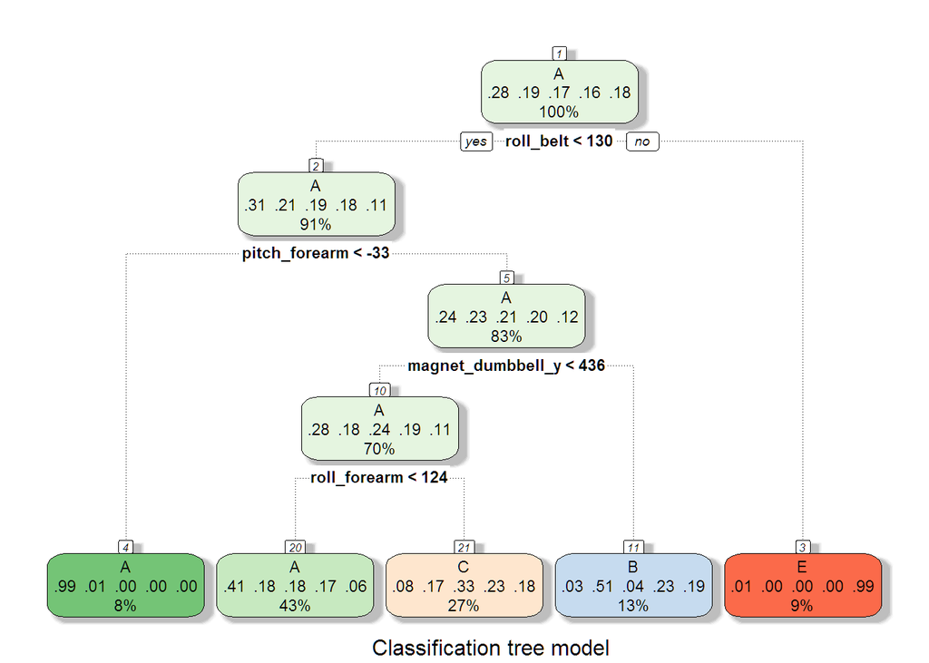

```r
#Fit the classification tree model
modTree <- train(classe ~., method = "rpart", data = training)
fancyRpartPlot(modTree$finalModel, sub = "Classification tree model")
```

Now, we estimate its accuracy:

```r
#Predict testing set
predTree <- predict(modTree, testing)

#Estimate accuracy
accuracyTree <- confusionMatrix(predTree, testing$classe)$overall[1]
```

The accuracy (0.49) is really poor, so we decide to fit a model with a random forest algortithm instead.

### *Random forest model*

- **Model fitting** : We fit a model on the training set with the Random Forest algorithm. We use a **10 fold-cross validation** to predict the ‘Classe’ of the subject based on all the predictors.

```r
#Fit a random forest model
fit <- train(classe ~. ,
             method = "rf",
             data = training,
             trControl = trainControl(method = "CV", number =10))
```

- **Accuracy**: We apply our model to the “testing” set and get the confusion matrix in order to estimate the accuracy and out of sample error rate of the model.

```r
#Predict testing set
pred <- predict(fit, testing)

#Accuracy
accuracy <- confusionMatrix(pred, testing$classe)$overall[1]
accuracy
```

```
##  Accuracy
## 0.9993203
```

From our analysis, our model has an accuracy of 0.999 and thus an **out of sample error of only 0.001**. This proves to be an excellent model to predict classe.

## Submission

Here is the code I used to predict the 20 observations’classes of the test set.

```r
#Predict testData Classe
submission <- predict(fit, testData)

#Write files (using the code provided on the project instruction page)
pml_write_files = function(x){
        n = length(x)
        for(i in 1:n){
                filename = paste0("problem_id_",i,".txt")
                write.table(x[i],file=filename,quote=FALSE,row.names=FALSE,col.names=FALSE)
        }
}
pml_write_files(submission)
```